# Use Of Force - Data from July 2020

Katja Janelle

August 3, 2020

**Update Graphs to be prettier**  
**Include outside demographics for area population**  
**pretty up the file so HTML looks nice for displaying**

# **Questions I’d Like to Answer:**

- Which precinct uses force the most?
- What are the total count of incidents by Race?
- What are the total count of incidents by Gender?
- What incident types are used the most?
- And on which groups?
- Has incidents increased over time, decreased, or stayed the same?

### **Which precinct uses force the most?**

Precinct

Total

Percentage

West

3198

28.06

North

2808

24.64

East

2015

17.68

South

2007

17.61

Southwest

653

5.73

X

368

3.23

342

3.00

2300 BLOCK CALIFORNIA AV SW

3

0.03

2700 BLOCK UTAH AV S

1

0.01

4200 BLOCK E MADISON ST

1

0.01

500 BLOCK S MAIN ST

1

0.01

5200 BLOCK UTAH AV S

1

0.01

**There is some bad data in this dataset…. going to remove those records from further analysis and re-run**

| Precinct | Total | Percentage |
| --- | --- | --- |
| West | 3198 | 29.94 |
| North | 2808 | 26.29 |
| East | 2015 | 18.87 |
| South | 2007 | 18.79 |
| Southwest | 653 | 6.11 |

**What areas represent each of the precincts?**

Data taken from SPD website: https://www.seattle.gov/police/about-us/police-locations/precinct-locator

| Precinct | Neighborhood |
| --- | --- |
| North | Ballard to U-District & Above |
| West | Downtown / Queen Anne |
| East | Capitol Hill / Central District |
| South | Columbia City / Beacon Hill (“Southeast Precinct” on website) |
| Southwest | West Seattle |

West Precinct makes sense to have the most with Downtown being heavily patrolled. Is West Seattle less crime-ridden or is West Seattle less patrolled?

### **What are the total count of incidents by Race?**

| Subject Race | Total | Percentage |
| --- | --- | --- |
| White | 4389 | 41.09 |
| Black or African American | 3469 | 32.48 |
| Not Specified | 1911 | 17.89 |
| Asian | 384 | 3.60 |
| Hispanic or Latino | 363 | 3.40 |
| American Indian/Alaska Native | 101 | 0.95 |
| Nat Hawaiian/Oth Pac Islander | 64 | 0.60 |

### **What are the total populations of each Race in Seattle?**

City of Seattle data on Demographics in Seattle as of 2018.  
Link (https://www.seattle.gov/opcd/population-and-demographics/about-seattle#raceethnicity)

| Race | Percentage |
| --- | --- |
| White | 64.5% |
| Black or African American | 6.8% |
| American Indian & Alaska Native | 0.5% |
| Asian | 14.9% |
| Native Hawaiian & Other Pacific Islander | 0.3% |
| Other race | 0.3% |
| Two or more races | 6.0% |
| Hispanic or Latino ethnicity (of any race) | 6.6% |

### What are the total count of incidents by Gender?

| Subject Gender | Total | Percentage |
| --- | --- | --- |
| Male | 8188 | 76.66 |
| Female | 2263 | 21.19 |
| Not Specified | 230 | 2.15 |

Men were subjected to use of force than Female subjects.

**Are men arrested more than women?**

### **What incident types are used the most?**

| Incident Type | Total | Percentage |
| --- | --- | --- |
| Level 1 - Use of Force | 8077 | 75.62 |
| Level 2 - Use of Force | 2420 | 22.66 |
| Level 3 - Use of Force | 104 | 0.97 |
| Level 3 - OIS | 80 | 0.75 |

Level 1 force is used the most with 8077 cases or 76% of total incidents. Level 2 follows next with 2420 cases of 23% of total incidents.

**What does each type mean for force??**

From: http://www.seattle.gov/police-manual/title-8---use-of-force/8050---use-of-force-definitions

| Type | Meaning |
| --- | --- |
| Level 1 | Force that causes transitory pain or the complaint of transitory pain. e.g. Hobble Restraint, Pointing Gun at individual, blast balls |
| Level 2 | Force that causes or is reasonably expected to cause physical injury greater than transitory pain but less than great or substantial bodily harm. e.g. taser, OC spray, Impact Weapon, canine attack |
| Level 3 - OIS | Office Involved Shooting (googled abbreviation) |
| Level 3 - Use of Force | Force that causes or is reasonably expected to cause, great bodily harm, substantial bodily harm, loss of consciousness, or death. e.g. impact weapon strike to the head |

### **What incident types are used the most and on which groups?**

| Incident Type | Subject Race | Total | Percentage |
| --- | --- | --- | --- |
| Level 1 - Use of Force | White | 3291 | 30.81 |
| Level 1 - Use of Force | Black or African American | 2638 | 24.70 |
| Level 1 - Use of Force | Not Specified | 1455 | 13.62 |
| Level 2 - Use of Force | White | 1019 | 9.54 |
| Level 2 - Use of Force | Black or African American | 772 | 7.23 |
| Level 2 - Use of Force | Not Specified | 432 | 4.04 |
| Level 1 - Use of Force | Asian | 295 | 2.76 |
| Level 1 - Use of Force | Hispanic or Latino | 286 | 2.68 |
| Level 2 - Use of Force | Asian | 76 | 0.71 |
| Level 2 - Use of Force | Hispanic or Latino | 75 | 0.70 |
| Level 1 - Use of Force | American Indian/Alaska Native | 69 | 0.65 |
| Level 1 - Use of Force | Nat Hawaiian/Oth Pac Islander | 43 | 0.40 |
| Level 3 - Use of Force | White | 42 | 0.39 |
| Level 3 - OIS | White | 37 | 0.35 |
| Level 3 - Use of Force | Black or African American | 31 | 0.29 |
| Level 2 - Use of Force | American Indian/Alaska Native | 28 | 0.26 |
| Level 3 - OIS | Black or African American | 28 | 0.26 |
| Level 2 - Use of Force | Nat Hawaiian/Oth Pac Islander | 18 | 0.17 |
| Level 3 - Use of Force | Not Specified | 17 | 0.16 |
| Level 3 - OIS | Asian | 7 | 0.07 |
| Level 3 - OIS | Not Specified | 7 | 0.07 |
| Level 3 - Use of Force | Asian | 6 | 0.06 |
| Level 3 - Use of Force | American Indian/Alaska Native | 4 | 0.04 |
| Level 3 - Use of Force | Hispanic or Latino | 2 | 0.02 |
| Level 3 - Use of Force | Nat Hawaiian/Oth Pac Islander | 2 | 0.02 |
| Level 3 - OIS | Nat Hawaiian/Oth Pac Islander | 1 | 0.01 |

Level 1 and 2 use of force used the most frequently and on Black and White individuals (makes sense with the two previous statements).

**Need to look at proportion of population is each group to compare to the percentage of use of force against each group.**

### **Has incidents increased over time, decreased, or stayed the same?**

**Group by Year**

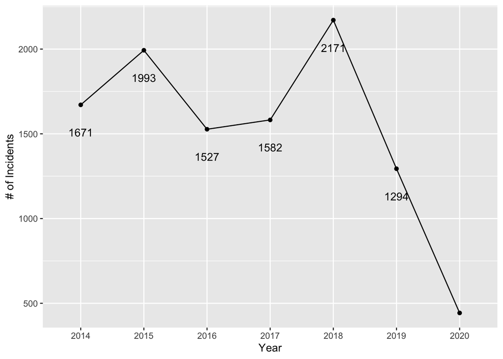

Since 2020 is not finished yet, it is hard to evaluate on current year but it does appear that within the last two years that the trend is decreasing (according to the data set).

Is there a seasonality trend on months that are more likely to have use of force incidents?

### **Is there a seasonality trend where which month has the most incidents?**

**Group by Month**

Going to exclude 2020 data in this since there is only data to beginning of July and I want to make sure it is more accurate to compare each month.

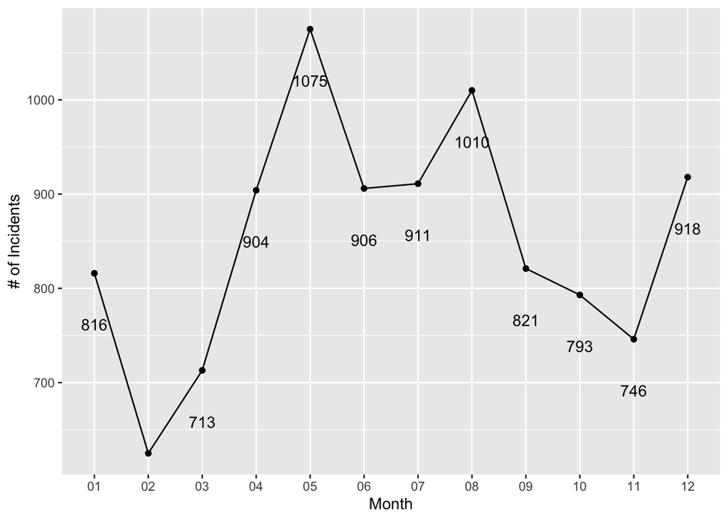